# Coursework Report

*N* removed NAs: 3

*N* removed typo: 1

*N* removed <18: 21

*N* total clean: 125

| Group | *N* | *M*<sub>age</sub> | *M*<sub>rating</sub> |
| --- | --- | --- | --- |
| Control | 71 | 20.9 | 5.44 |
| Experim | 54 | 20.6 | 6.50 |

**Main analysis results**

*t*(123) = -6.3, *p* < .001

[interactive chart not shown]

[figure not shown]

[interactive chart not shown]

# Coursework Report

Analysing Data, Spring 2020, Candidate: 218325

This student has a record of specific learning difficulty (dyslexia/dyspraxia). Please mark this report in accordance with the [marking guidelines for SLD](https://www.sussex.ac.uk/studentsupport/staff/spld?fbclid=IwAR2lYKD6xvuv9egQDvG8d_oed9GUD3KXQn3gAdlHZ1gQB8gDddBdeOEmKdE).

# Methods

## Participants

**Figure 1** *A Table to show Participants’ Descriptives by Experimental Condition*

[output not shown]

## Design

In this experiment, we hoped to find out whether colour does indeed influence perceived attractiveness. We aimed to replicate the Elliot et al (2010) experiment where the goal was to see whether women find men more attractive in conjunction with the colour red. To be used as a comparitive colour to red, white was chosen as the Control variable as it is a neutral colour compared to the vibrancy of the red. This created two levels of independant variables. (Elliot et al, 2010)

Participants were asked to look at a black and white photograph of a man on a white frame (the Control variable) or red frame (the Experimental variable) background. Each photograph was 4 x 6 inches, showing a head and shoulders of a reasonably appealing Caucasian, brown-haired man, wearing a plain shirt. Each photograph set is a standard one was originally used by both Elliot et al (2010) and Corneille, Monin, & Pleyers (2015). After looking at each type of photograph, the participants were asked to record their perceptions of the man’s level of attractiveness.

For our continous variable, we measured the level of attractiveness by posing three different questions to each participant: *“How attractive do you think this person is?”*, *“How pleasant is this person to look at?”*, and, *“If I met the person face to face, would I think he is attractive?”*. Each question was answered on a 1 to 9 scale, starting at 1 with *Not at all* to 9 with *Exceptionally Attractive*.(Elliot et al, 2010) A low score meant that the participant did not perceive the man in the photograph to be attractive. A high score meant that they thought the man to be very attractive. These scores applied whether the photography white or red background. The final question of *“If I met the person face to face, would I think he is attractive?”* was to introduce an element of theorectical attractiveness of the photographed male in person not only on paper.

We hypothesised that the female participants would find the photographed male more attractive on the red frame than on the white frame.

To test this hypothesis, we compared the mean scores of both the *Experimental* colour of the red frame with the *Control* colour of white frame. Which ever had the greater mean score would be higher on the percieved attractiveness scale. We also compared the average answers in a composite index score to see if there was a pattern in the overall scores. Due to the fact that the colour white is less eye catching than red, we believed that the women would be more drawn to the photograph in the red frame. Thus, we expected to see that the red frame mean score would be higher than that of the white frame.

# Results

**Figure 2** *A Scatter Plot to show The Mean Attractiveness Ratings with Both Control and Experimental Colour Conditions*

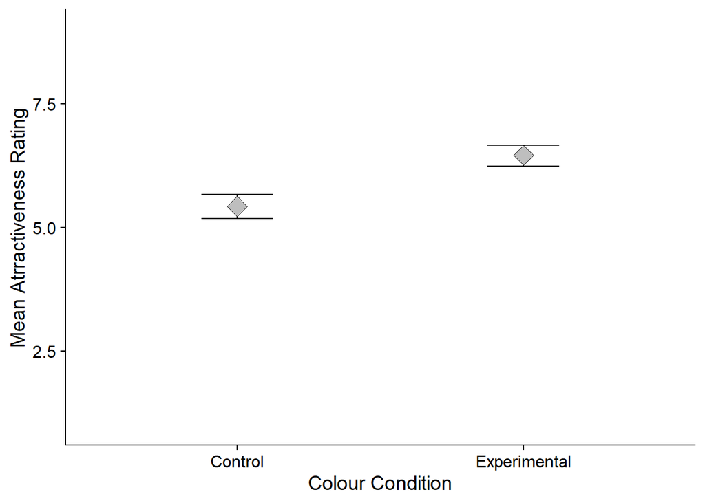

# Discussion

The experiment provided evidence which supported the research hypothesis that colour can influence perceived attractiveness. The results showed that the Experimental condition of the photograph on the red frame background was clearly perceived to be more attractive than the Control condition of the photograph on the white-frame background. The results showed this as the red-frame condition scored higher across the three separate questions than the white-frame condition.

This result is supported by other researchers who found that the hypothesis of the colour red effecting the level of attractiveness. Elliot et al (2010) found a clear influence of the colour red on which photograph was perceived to be more attractive. The photograph on the red frame had a *M*score of 6.79 whilst the white framed photograph had a *M*score of 5.67. This was similar to our results.

However, Wen et al (2014) carried out a similar study using 150 Chinese women, having them judge the attractiveness of a man in red t-shirt, white t-shirt or blue t-shirt. The difference in this study to ours was that there was an additional aim to measure how greatly the perception of “masculine” features effected levels of attractiveness as well as the colour red. Each photograph was digitally enhanced to show a more feminine vs. a more masculine version of each the man. (Wen et al, 2014) Wen et al (2014) found that the red t-shirt effected attractiveness on by a small margin whilst the masculine features had a greater effect. Thus, the man who was digitally edited to look more masculine was more attractive to the female participants in the red t-shirt than the white or blue. A further study could be undertaken to measure if a masculine man in red is more attractive than a ‘none’ masculine man in red without any digital enhancing. Wen et al (2014) noted that the results are applicable to Chinese women, so a further study on non-specific ethnicities would provide a better understanding in a more multicultural population as we have in the United Kingdom.

The limitation of our study was that only two colours were used to measure attractiveness. To produce a more thorough representation of whether attractiveness in relation to the colour red is more influential, more colours should be present in the experiment. Perhaps if the experiment were to be repeated but with other colours than red and white, there would be less of a psychological bias towards the colour red, as red is automatically more alluring than white.(Elliot et Maier, 2014) Elliot et al (2010) mentioned that they found that there participants were unaware of any colour influence on their choices, but I believe there should be a greater variety to eliminate any possibility.

In addition, there may have been a section of participants who did indeed know that they were to be measured on influence by colour. The introduction to the experiment should be more ambiguous as to what is being measured, i.e. let the participants know they must choose who is more attractive but try to not signal to them a colour is being considered. (Elliot et al, 2010) Because of the instructions, we found that our participants naturally knew they were to compare the two photographs, which means we were unable to comment on whether a choice was forced. There might also have been an element of bias where the female participants felt they had to find at least one of the photographs more attractive, as they knew there would be a comparison in the data. A more varied number of colours would prevent such a bias. The introduction of a further option in the questions, for example, *“I do not find this man attractive”* or something similar, would invite a more organic reaction to the photographs.

A further study in the future could be carried out an experiment using men as participants also, similarity to Wen et al (2014). We could measure whether gender can influence how we perceive attractiveness, i.e. do men or women perceive red to be a more appealing colour.

Previous studies have been carried out in regards to men finding women more attractive when wearing red as well as women finding men more attractive in red, (Peperkoorn, Roberts & Pollet, 2016) but other than Wen et al (2014), there are few that compare men vs women. Another gap in research is the consideration of the influence of colour on same sex attraction. Wen et al (2014) also invited his participants to judge the same gender i.e.. the colour and attractiveness, but I think this could be researched further.

To summarise, red does influence how attractive women see men. (Wen et al, 2014) However, this study does not show how gender, sexual preference or ethnicity may influence how we perceive attractiveness. As Elliot et al (2010) stated at the end of this experiment, this is a ‘promising’ area of research that researchers need to consider in further. (Elliot et al, 2010, p.412)

# References

Elliot, A. J., Greitemeyer, T., Gramzow, R. H., Kayser, D. N., Lichtenfeld, S., & Maier, M. A. (2010) Red, Rank, and Romance in Women Viewing Men. *Journal of Experimental Psychology: General*. Washington, DC: American Psychological Association. 139: 3, 399-417. Available at: http://www.baomee.info/pdf/Romance/0.pdf. Acessed 22nd April, 2020.

Elliot, A. & Maier, M. A., (2014) Color Psychology: Effects of Perceiving Color on Psychological Functioning in Humans. *Annual Review of Psychology*, 65, 95-120. Available at: https://www.annualreviews.org/doi/abs/10.1146/annurev-psych-010213-115035. Assessed: 27th April 2020

Hesslinger, V.M., Goldbach, L. & Carbon, C. Men in red: A reexamination of the red-attractiveness effect. *Psychonomic Bulletin & Review* 22, 1142–1148. https://doi.org/10.3758/s13423-015-0866-8

Peperkoorn, L. S., Roberts, S. C., & Pollet, T. V. (2016) Revisiting the Red Effect on Attractiveness and Sexual Receptivity: No Effect of the Color Red on Human Mate Preferences. *Evolutionary Psychology*, Sage Journals, 1-13. Available at: https://doi-org.ezproxy.sussex.ac.uk/10.1177%2F1474704916673841

Wen, F., Zuo, B., Sun, S., & Liu, K. (2014) Sexual Dimorphism Moderates Red Effect on Sexual Attraction. *Evolutionary Psychology*: Sage Journals, 12, 719-735. https://psycnet.apa.org/doi/10.1177/147470491401200404

Word Count: 1,837